# South African COVID-19 Modelling Consortium

National COVID Epi Model

# NCEM v1.0 (Provincial Model): Supplementary information

This document provides a technical overview of the National COVID-19 Epi Model (NCEM) provincial model. The model described in this document is the provincial-level NCEM model, created by the [South African COVID-19 Modelling Consortium](https://saCOVID19mc.github.io). There is also a separate document, the [NCEM Provincial Model Code Guide](https://sacovid19mc.github.io/ncemProvincialCodeGuide.pdf), that gives an overview of the structure of the model code. If there are any queries regarding the model or the code, please contact us on: info@sacovid19mc.co.za.

## Model equations

The model describes the temporal evolution of the following state variables:

| Variable | Definition |
| --- | --- |
| *S* | number of susceptible individuals |
| *E* | number of exposed but not yet infectious individuals |
| *I*<sub>*A*</sub> | number of asymptomatic individuals (infectious) |
| *I*<sub>*P*</sub> | number of presymptomatic individuals (infectious) |
| *I*<sub>*M*</sub> | number of mildly and moderately ill individuals (infectious) |
| *I*<sub>*S*</sub> | number of individuals who are or will become severely ill but are not yet hospitalised (infectious) |
| *H*<sub>1</sub> | number of severely ill individuals who are hospitalized in the general (non-ICU) ward |
| *H*<sub>2</sub> | number of individuals who are work will be come critically ill currently in the general (non-ICU) ward |
| *C*<sub>1</sub> | number of individuals who are critically ill, will eventually die, and are currently in the ICU |
| *C*<sub>2</sub> | number of individuals who are critically ill, will eventually recover, and are currently in the ICU |
| *H*<sub>3</sub> | number of individuals who have been critically ill, will recover, and have been discharged from the ICU but remain in hospital for step-down care |
| *R* | number of individuals who are no longer infectious / recoverd and/or discharged |
| *D* | number of individuals who have died |
| *I*<sub>*M*<sub>*d*</sub></sub> | cumulative number of *confirmed* mild / morderate infections |
| *I*<sub>*S*<sub>*d*</sub></sub> | cumulative number of *confirmed* severe and critical infections |
| *N* | total number of individuals in the population (*S* + *E* + *I*<sub>*A*</sub> + *I*<sub>*P*</sub> + *I*<sub>*M*</sub> + *I*<sub>*S*</sub> + *H*<sub>1</sub> + *H*<sub>2</sub> + *C*<sub>1</sub> + *C*<sub… |
| *X* | dummy variable representing mild and moderate cases who will be tested before they are tested |
| *Y* | dummy variable representing severe and critical cases who will be tested before they are tested |

The following equations describe the dynamics of transmission and disease progression within each province, *x*:

$$\frac{dS_x}{dt} = - \Phi_x S_x$$
$$\frac{dE_x}{dt} = \Phi_x S_x - \gamma_1 E_x$$
$$\frac{dI_{A_x}}{dt} = p_a \gamma_1 E_x - r_1 I_{A_x}$$
$$\frac{dI_{P_x}}{dt} = (1-p_a) \gamma_1 E_x - \gamma_2 I_{P_x}$$
$$\frac{dI_{M_x}}{dt} = p_{m_x} \gamma_2 I_{P_x} - r_2 I_{M_x}$$
$$\frac{dI_{S_x}}{dt} = (1-p_{m_x}) \gamma_2 I_{P_x} - \tau_s I_{S_x}$$
$$\frac{dH_{1_x}}{dt} = \left(1-\frac{p_{c_x}}{(1-p_{m_x})}\right) \tau_s I_{S_x} - r_3 H_{1_x}$$
$$\frac{dH_{2_x}}{dt} = \frac{p_{c_x}}{(1-p_{m_x})} \tau_s I_{S_x} - \tau_p H_{2_x}$$
$$\frac{dC_{1_x}}{dt} = d_{c_x} \tau_p H_{2_x} - \mu C_{1_x}$$
$$\frac{dC_{2_x}}{dt} = (1-d_{c_x}) \tau_p H_{2_x} - r_4 C_{2_x}$$
$$\frac{dH_{3_x}}{dt} = r_4 C_{2_x} - r_5 H_{3_x}$$
$$\frac{dR_x}{dt} = r_1 I_{A_x} + r_2 I_{M_x} + (1-d_{s_x}) r_3 H_{1_x} + r_5 H_{3_x}$$
$$\frac{dD_x}{dt} = d_{s_x} r_3 H_{1_x} + \mu C_{1_x}$$
$$\frac{dX_x}{dt} = d_m p_{m_x} \gamma_2 I_{P_x} - \Delta_m {X_x}$$
$$\frac{dY_x}{dt} = d_s \tau_s I_{S_x} - \Delta_s {Y_x}$$
$$\frac{dI_{M_d}}{dt} = \Delta_m {X_x}$$
$$\frac{dI_{S_d}}{dt} = \Delta_s {Y_x}$$

where the force of infection, *Φ*<sub>*x*</sub>, is defined as
$$\Phi_x = \frac{\beta_{x} \delta_{x,t} \left(\zeta I_{A_x}+I_{P_x}+I_{M_x}+I_{S_x}\right)}{N_x}$$
and *p*<sub>*c*<sub>*x*</sub></sub> = 1 − *p*<sub>*m*<sub>*x*</sub></sub> − *p*<sub>*s*<sub>*x*</sub></sub>.

## Parameter definitions

Model parameters and the values used are defined in the tables below. The first table contains parameters that are the same across provinces; the second contains parameters that vary across provinces. To take into account parametric uncertainty, we varied key parameters, drawing them stochastically from a triangular distribution defined by the lower, upper, and mode values as given in the tables.

| Symbol | Code | Description | Mode | Lower | Upper | Units |
| --- | --- | --- | --- | --- | --- | --- |
| *γ*<sub>1</sub> | gamma1 | 1 / duration in exposed class (*E*) | 91.25 | 60.83 | 182.50 | years<sup>− 1</sup> |
| *γ*<sub>2</sub> | gamma2 | 1 / duration in presymptomatic class (*I*<sub>*P*</sub>) | 182.50 | 121.67 | 365.00 | years<sup>− 1</sup> |
| *r*<sub>1</sub> | r1 | 1 / duration of infectiousness for asymptomatic infections (*I*<sub>*A*</sub>) | 52.14 | 45.62 | 60.83 | years<sup>− 1</sup> |
| *r*<sub>2</sub> | r2 | 1 / duration of infectiousness for mild and moderate cases (*I*<sub>*M*</sub>) | 73.00 | 60.83 | 91.25 | years<sup>− 1</sup> |
| *μ* | mu | 1 / time to from entry into ICU until death for critical cases who will die (*C*<sub>1</sub>) | 73.00 | 60.83 | 91.25 | years<sup>− 1</sup> |
| *R*<sub>0</sub> | R0 | basic reproduction number | 2.70 | 2.60 | 2.80 | years<sup>− 1</sup> |
| *τ*<sub>*s*</sub> | taus | 1/ time from onset to hospitalisation for severe cases (*I*<sub>*S*</sub>) | 73.00 | 60.83 | 91.25 | years<sup>− 1</sup> |
| *p*<sub>*a*</sub> | pa | proportion of infections that will remain asymptomatic | 0.75 | 0.70 | 0.80 | - |
| *τ*<sub>*p*</sub> | tauprog | 1 / time from hospitalisation to ICU admission for critical cases | 91.25 | 73.00 | 182.50 | years<sup>− 1</sup> |
| *ζ* | zeta1 | relative infectiousness of asymptomatic infections | 0.75 | 0.70 | 0.80 | - |
| *r*<sub>3</sub> | r3 | 1 / duration of hospital stay for severe cases | 30.42 | 26.07 | 45.62 | years<sup>− 1</sup> |
| *r*<sub>4</sub> | r4 | 1 / duration of stay in ICU for critical cases | 22.81 | 20.28 | 26.07 | years<sup>− 1</sup> |
| *d*<sub>*m*</sub> | pdetm | proportion of mild cases detected | 0.25 | 0.25 | 0.25 | - |
| *d*<sub>*s*</sub> | pdets | proportion of severe cases detected | 1.00 | 1.00 | 1.00 | - |
| *Δ*<sub>*m*</sub> | deltam | 1 / time from onset to test result for mild and moderate cases | 45.62 | 36.50 | 91.25 | years<sup>− 1</sup> |
| *Δ*<sub>*s*</sub> | deltas | 1 / time from onset to test result for severely ill cases | 91.25 | 73.00 | 182.50 | years<sup>− 1</sup> |
| *r*<sub>5</sub> | r5 | 1 / duration in step-down care after discharge from ICU | 121.67 | 91.25 | 182.50 | years<sup>− 1</sup> |

| Symbol | Code | Definition | Eastern Cape | Free State | Gauteng | Kwa-Zulu Natal | Limpopo | Mpumalanga | Northern Cape | North West | Western Cape |
| --- | --- | --- | --- | --- | --- | --- | --- | --- | --- | --- | --- |
| *p*<sub>*m*<sub>*x*</sub></sub> | pm | proportion of symptomatic cases that are mild or moderate | 0.95 | 0.95 | 0.95 | 0.96 | 0.96 | 0.96 | 0.95 | 0.96 | 0.95 |
| *p*<sub>*s*<sub>*x*</sub></sub> | ps | proportion of symptomatic cases that are severe | 0.03 | 0.04 | 0.04 | 0.03 | 0.03 | 0.03 | 0.04 | 0.03 | 0.04 |
| *d*<sub>*s*<sub>*x*</sub></sub> | pd1 | proportion of severely ill (not critical) cases who die | 0.00 | 0.00 | 0.00 | 0.00 | 0.00 | 0.00 | 0.00 | 0.00 | 0.00 |
| *d*<sub>*c*<sub>*x*</sub></sub> | pd2 | proportion of critically ill cases who die | 0.29 | 0.27 | 0.24 | 0.26 | 0.27 | 0.26 | 0.27 | 0.25 | 0.26 |

## Basic reproduction number

The expected number of secondary infections produced by a single infection introduced into a naive population (basic reproduction number) can be caluclated as:
$$R_{0_x} = \beta_{x,0} \left(\frac{p_a \zeta}{r_1} + \frac{(1-p_a)}{\gamma_2} + \frac{(1-p_a) p_{m_x}}{r_2} + \frac{(1-p_a)(1-p_{m_x})}{\tau_s}\right)$$
In this context, a ‘naive’ population is the population at the start of the epidemic when (a) there are no previously-infected individuals (*S*<sub>*x*</sub> ≈ *N*<sub>*x*</sub>) and (b) there are no measures or practices in place that reduce the contact rate below baseline (*δ*<sub>*x*, 0</sub> = 1).

## Time-varying reproduction numbers

The reproduction number is assumed to vary over time, reflecting changes in the contact rate that result from both government-enforced and individually-enacted measures. We refer to two types of time-varying reproduction numbers: *R*<sub>*c*</sub>(*t*) = *δ*<sub>*t*</sub>*R*<sub>0</sub> denotes the hypothetical reproduction number at a given point in time that would be observed in the absence of previously-infected individuals, where *δ*<sub>*t*</sub> is a proportional reduction from baseline; *R*<sub>*e*</sub>(*t*) = *R*<sub>*c*</sub>(*t*)*S*(*t*)/*N*(*t*) denotes the realized reproduction number at a given point in time, taking into account accumulation of infeciton and immunity in the population.

## Scenarios

We consider two scenarios, an optimistic and a pessimistic scenario, as described in detail in our published reports[^1],[^2]. The scenarios can be summarized based on how the value of *δ*<sub>*t*</sub> (and therefore *R*<sub>*c*</sub>(*t*)) varies through time, as depicted below. A no intervention scenario is also shown for comparison.

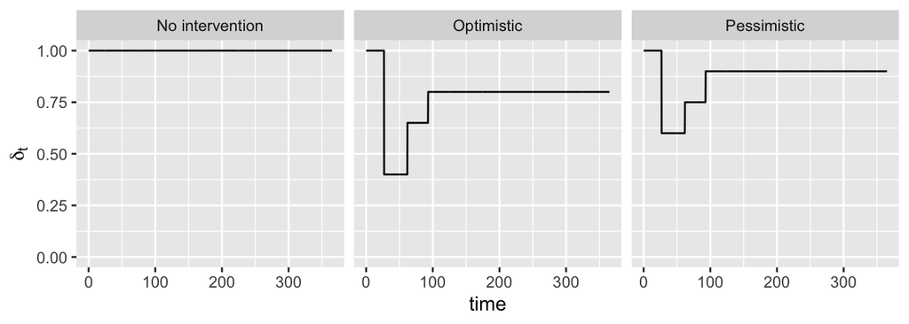

This work is licensed under a [Creative Commons Attribution 4.0 International License](http://creativecommons.org/licenses/by/4.0/).

## References

[^1]: MASHA, HE2RO, SACEMA, and NICD, on behalf of the South African COVID-19 Modelling Consortium. (2020) “Estimating cases for COVID-19 in South Africa: Long-term national projections” https://www.nicd.ac.za/wp-content/uploads/2020/05/SACovidModellingReport_NationalLongTermProjections_Final.pdf
[^2]: MASHA, HE2RO, SACEMA, and NICD, on behalf of the South African COVID-19 Modelling Consortium. (2020) “Estimating cases for COVID-19 in South Africa: Long-term provincial projections” https://www.nicd.ac.za/wp-content/uploads/2020/05/SACovidModellingReport_ProvincialLongTermProjections_Final.pdf

[South African COVID-19 Modelling Consortium](https://saCOVID19mc.github.io)

*info@sacovid19mc.co.za*